# TFM 1

#### Outliers df_all_tables/Total_Sales

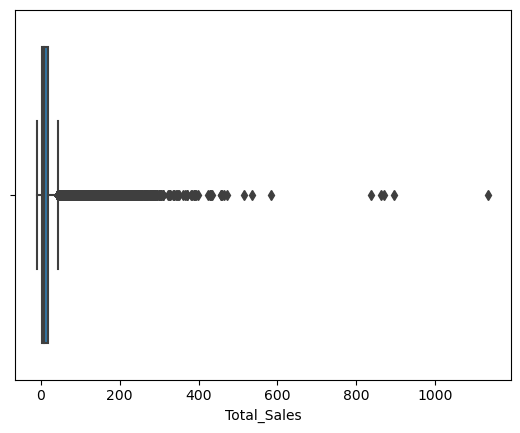

```python
#Total_Sales:
sns.boxplot(x=df_all_tables['Total_Sales'])
plt.show()
```

Tenemos el mismo problema, muchos outliers.

```python
#Usamos el método IQR para Total_Sales:

Q1 = df_all_tables['Total_Sales'].quantile(0.25)
Q3 = df_all_tables['Total_Sales'].quantile(0.75)
IQR = Q3 - Q1

lower_bound = Q1 - 2 * IQR
upper_bound = Q3 + 2 * IQR

outliers3 = df_all_tables[(df_all_tables['Total_Sales'] < lower_bound) | (df_all_tables['Total_Sales'] > upper_bound)]
print(outliers3)
```

```
        Month Affiliated_Code Affiliated_NAME  POSTALCODE  \
1           5         WsnaAAD      LISBOA-445       28850
6           8         WUWlAAP       GALÉS-204       46017
12          7         WteeAAD       RIOJA-510       50017
24          3         WuM5AAL      BORRUL-350       46008
61          3         Wsx7AAD       MAYOR-303       28723
...       ...             ...             ...         ...
354256      5         WUiDAAX     BOLONIA-104       11510
354264      8         Wl83AAD       MAYOR-742       50630
354274      7         WsQjAAL       RAMON-381       13350
354291      4         XChQAAX      PUERTO-814        5450
354328      4         WUEZAA5        PESO-090       41450

                    poblacion          provincia  Engage  Management_Cluster  \
1       Barrio De El Castillo             Madrid       3                   0
```

[output cut: 38 more lines]

También obtenemos muchos outliers para un umbral de 2: 20304

```python
#Realizaremos el mismo ejercicio con el método Z-Score para Total_Sales.

threshold = 2
outliers4 = df_all_tables[np.abs(stats.zscore(df_all_tables['Total_Sales'])) > threshold]

print(outliers4)
```

```
        Month Affiliated_Code Affiliated_NAME  POSTALCODE  \
1           5         WsnaAAD      LISBOA-445       28850
6           8         WUWlAAP       GALÉS-204       46017
12          7         WteeAAD       RIOJA-510       50017
24          3         WuM5AAL      BORRUL-350       46008
61          3         Wsx7AAD       MAYOR-303       28723
...       ...             ...             ...         ...
354237      5         WU1TAAX        JUAN-217       28911
354255      4         WqhLAAT       RAMON-590       22001
354256      5         WUiDAAX     BOLONIA-104       11510
354274      7         WsQjAAL       RAMON-381       13350
354328      4         WUEZAA5        PESO-090       41450

                    poblacion          provincia  Engage  Management_Cluster  \
1       Barrio De El Castillo             Madrid       3                   0
```

[output cut: 38 more lines]

En este caso los outliers se limitan a 16543 registros con un umbral de 2. Este será el método con el que eliminaremos outliers de Total_Sales.

#### Outliers df_all_tables/Total_OoS

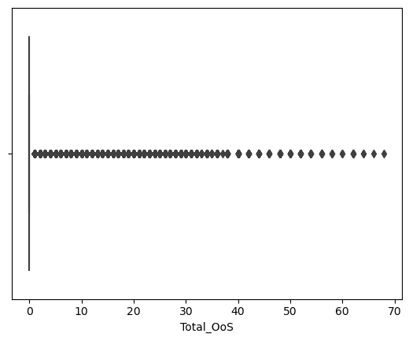

```python
#En el caso de Total_OoS tenemos:

sns.boxplot(x=df_all_tables['Total_OoS'])
plt.show()
```

Como vemos la mayoría de registros está en 0, por lo que se considera que todo lo que está por encima de 0 es outlier.

En este caso no trataremos los valores por encima de 0 como outliers, ya que de lo contrario nos quedaremos sin datos para estudiar la rotura.

#### Tratamiento de Outliers para df_all_tables

En el caso de df_all_tables eliminaremos los outliers obtenidos con zscore para Total_Sales y Total_Delivered.

Se están perdiendo muchas filas pero al tratarse de un dataset muy grande no creemos que impacte tanto en los posteriores algoritmos que aplicaremos, que además como veremos en algunos casos no pueden gestionar correctamente todos los datos y necesitan realizar sampling para algunos algoritmos.

```python
#Como queremos tratar los outliers de 2 columnas de df_all_tables, realizaremos una unión de ellas y luego drop:

outliers_indices = outliers2.index.union(outliers4.index)

df_all_tables_no_outliers = df_all_tables.drop(outliers_indices)
```

Podríamos haber usado una intersección para realizar el drop, pero en ese caso nos hubieramos quedado con muchos de los outliers sin drop.

```python
#Además haremos un drop de los valores negativos de estas 2 columnas,
#ya que es posible que afecten a los resultados de análisis posteriores.

df_all_tables_no_outliers  = df_all_tables_no_outliers[(df_all_tables_no_outliers ['Total_Delivered'] >= 0)
                                                       & (df_all_tables_no_outliers ['Total_Sales'] >= 0)]
```

El eliminar los valores negativos ha permitido también mejorar el desempeño de los algoritmos y algun feature que no funcionaba bien con ese tipo de valores.

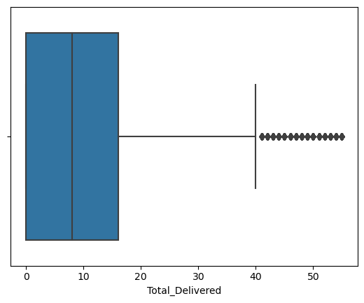

```python
#Revisamos de nuevo los outliers
sns.boxplot(x=df_all_tables_no_outliers['Total_Delivered'])
plt.show()
```

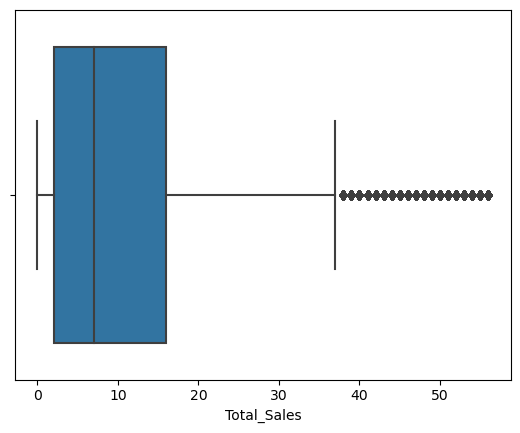

```python
#Lo mismo para Total_Sales
sns.boxplot(x=df_all_tables_no_outliers['Total_Sales'])
plt.show()
```

Después de comparar varios thresholds para delimiar outliers, hemos decidido usar un 2, ya que mayores thresholds hacían que apareciesen más outliers en la segunda revisión de los mismos al cambiar la distribución de los valores.

Para df_Delivery_Route no tenemos columnas numéricas para estudiar outliers, ya que son campos categóricos.

#### Outliers df_Sales_Rotura/Sales_Uds

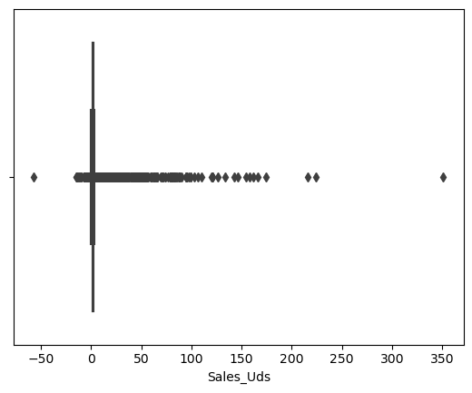

```python
#Revisamos el plot:

sns.boxplot(x=df_Sales_Rotura['Sales_Uds'])
plt.show()
```

```python
#Para df_Sales_Rotura podemos de nuevo estudiar Sales_Uds pero en este caso a nivel de día,
#por lo que tendremos más filas y más outliers

Q1 = df_Sales_Rotura['Sales_Uds'].quantile(0.25)
Q3 = df_Sales_Rotura['Sales_Uds'].quantile(0.75)
IQR = Q3 - Q1

lower_bound = Q1 - 5 * IQR
upper_bound = Q3 + 5 * IQR

outliers5 = df_Sales_Rotura[(df_Sales_Rotura['Sales_Uds'] < lower_bound) | (df_Sales_Rotura['Sales_Uds'] > upper_bound)]
print(outliers5)
```

```
         Sales_DAY Affiliated_Code  POSTALCODE           poblacion  \
23      2015-08-28         WoYgAAL        8810           Puigmolto
48      2015-08-24         WuYyAAL       28925            Alcorcon
521     2015-08-28         WUA5AAP       49300  Puebla De Sanabria
523     2015-08-28         XCxbAAH       18198         Huetor Vega
700     2015-08-25         XCOxAAP       33400              Aviles
...            ...             ...         ...                 ...
2877056 2015-06-14         WURBAA5       43430             Vimbodi
2877447 2015-08-16         XA58AAH        3600           Agualejas
2877478 2015-08-06         WjyOAAT       11520         Bercial, El
2877815 2015-09-27         XCxeAAH        6001             Badajoz
2877840 2015-09-22         XCxeAAH        6001             Badajoz

                provincia Product_Code  Sales_Uds OoS_DAY Rotura  \
23              Barcelona      Natu079         11     NaT     No
```

[output cut: 25 more lines]

En este caso llegamos a las 40943 outliers con un umbral de 5.

Vemos que tenemos muchos outliers también

```python
#Si usamos el método zscore sobre los mismos datos:

threshold = 3
outliers6 = df_Sales_Rotura[np.abs(stats.zscore(df_Sales_Rotura['Sales_Uds'])) > threshold]

outlier_indices6 = outliers6.index

print(outlier_indices6)
```

```
Int64Index([     23,      48,     521,     523,     700,     833,     966,
               1629,    1709,    1725,
            ...
            2876093, 2876269, 2876451, 2876709, 2876866, 2877056, 2877447,
            2877478, 2877815, 2877840],
           dtype='int64', length=40951)
```

Obtenemos para el mismo campo 40951 outliers pero con un umbral menor (de 3), por lo que usaremos este método para eliminar los outliers.

```python
#Hacemos drop para los outliers de df_Sales_Rotura para la columna Sales_Uds usando los resultados de Zscore

df_Sales_Rotura_no_outliers = df_Sales_Rotura.drop(outlier_indices6)
```

```python
#Ahora también eliminaremos los valores por debajo de 0

df_Sales_Rotura_no_outliers  = df_Sales_Rotura_no_outliers[(df_Sales_Rotura_no_outliers['Sales_Uds']>= 0)]
```

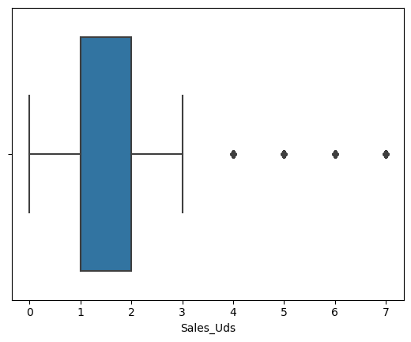

```python
sns.boxplot(x=df_Sales_Rotura_no_outliers['Sales_Uds'])
plt.show()
```

Tendremos muchos menos outliers en este caso, habiendo eliminado también los valores negativos.